{% raw %}

# Are all Cigarettes after Sex songs the same?

Author

Jonne Huiveneers

The band Cigarettes after sex often get accused of the fact that all of their songs are very similar Like by this X user:

[figure not shown]

There are two things about me that you should know. Firstly I love Cigarettes after sex and secondly I love arguing with people on the internet.

That is why I am going to launch a scientific inquiry into the correctness of this online comment.

## Who are cigarettes after sex?

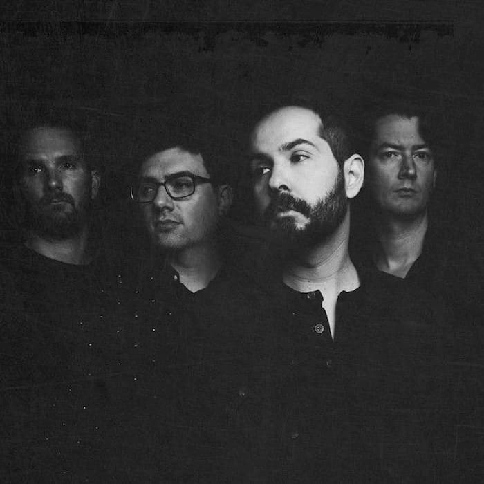

Cigarettes After Sex often abbreviated as (CAS) is an American ambient pop band formed in 2008 by front man Greg Gonzalez. Known for their dreamy, slow-burning sound, the band blends ethereal guitars, soft percussion, and hushed, androgynous vocals to create an intimate and melancholic atmosphere.

They gained widespread attention with their breakout single [Nothing’s Gonna Hurt You Baby](https://www.youtube.com/watch?v=QI8VrXkffcg), which became a viral favorite years after its release. Their self-titled debut album, Cigarettes After Sex, established their signature minimalist style, characterized by themes of romance, longing, and nostalgia.

Often described as cinematic and emotionally raw, Cigarettes After Sex has built a global following through their consistent aesthetic and immersive live performances.

## Scope of the investigation

To make sure that we truly capture the style of CAS we will only include songs that they have published in albums as to avoid special project which might skew the results. Something will be labeled an album if it is mentioned as an album on Spotify. If we use these rules we find that CAS has published three albums: Cigarettes after sex (2017), Cry (2019), X’s (2024)

Before any kind of data analysis we will of course need tools. For this project I will be using Rstudio and the following libraries. These will help me to properly analyse all the data and make prettier graphics.

```r
library(ggplot2)
library(dplyr)
library(plotly)
library(readr)
library(tinytable)
library(rempsyc)
```

## Intro

To analyse data we will of course also need data I used the 2023 Spotify singer database but because it ends in 2023 I needed to manually add X’s as it came out after 2023. For this I used Dr. Joy lee’s website however this website records different data and uses different variable names which we will need to fix. When I was checking the data I also noticed that there were a few small mistakes where the acoustciness of ‘holding you, holding me’ was replaced by ‘holding me’ . I found out that this was due to the fact that the database uses “,” to separate value’s so it split the title into two. After I figured this out I discovered that the problem was actually much bigger, because the holding me had taken up the slot to its right all of the other data points in the row had also moved over by one, and had even made a new row to fit all the data points. This needed fixing before i could start.

```r
#Step 1.
#We standardized all the names so both databases are speaking the same language
x_s <- rename(x_s,
               track_name = Song,
               energy = Energy,
               valence = Valence,
               danceability = Danceability,
               loudness = Loudness,
               speechiness = Speechiness,
               liveness = Liveness,
               tempo = Tempo,
               acousticness = Acousticness,
               instrumentalness = Instrumentalness)


#Step 2.
#We remove the extra row
x_s <- x_s[-6,]

#Step 3
#We fix the entry in row 5
x_s[5, "artist_name"] <- "Cigarettes After Sex"
x_s[5, "album_release_year"] <- 2024
x_s[5, "energy"] <- 0.465000
x_s[5, "valence"] <- 0.599
x_s[5, "danceability"] <- 0.620000
x_s[5, "loudness"] <- -10.778
x_s[5, "speechiness"] <- 0.0311
x_s[5, "liveness"] <- 0.113000
x_s[5, "tempo"] <- 114.005
x_s[5, "acousticness"] <- 0.480
x_s[5, "instrumentalness"] <- 0.895000

#Step 4.
#In the x_s database everything was stored as text but as numbers in CAS. So we need to turn everything into a number if we want to combine them and also to analyse it later.

x_s <- x_s %>%
  mutate(across(c(valence, energy, danceability, loudness,
                  speechiness, liveness, tempo,
                  acousticness, instrumentalness), as.numeric))

#Step 5.
# After making both datasets compatible we can finally combine them into one big one
df <- bind_rows(CAS, x_s)
```

After this the data set is almost ready for analysis. It still contains NA values because the two data sets did not record the same metrics but we won’t be needing these metrics for the analysis anyways, so we will not fill them in except for the album names as we will be using these later on to compare the three different albums to each other.

```r
df[20:29, "album_name"] <- "X's"
```

## Start of the analysis

Given that Cigarettes After Sex are known for being very dreamy, slow, and consistent in sound, I will focus especially on energy, valence, and tempo as these will likely show the most interesting patterns. Energy means how energetic a song is deemed to be on a scale from 0 - 1. Valence is how happy a song is also on a scale from 0 - 1. Tempo is measured in beats per minute and does not have a predetermined scale.

A good way to start analyzing data is by making a boxplot as this allows you to view some general characteristics of the data you are working with. But I personally like density plots as they give me a feeling for the shape of the data. I decided to combine them here so they take up less space.

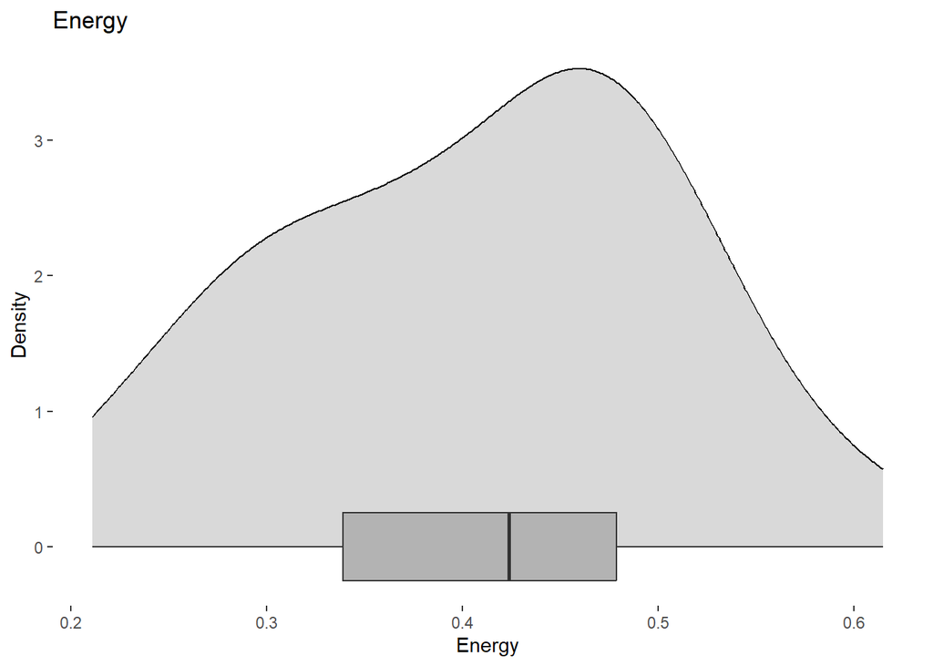

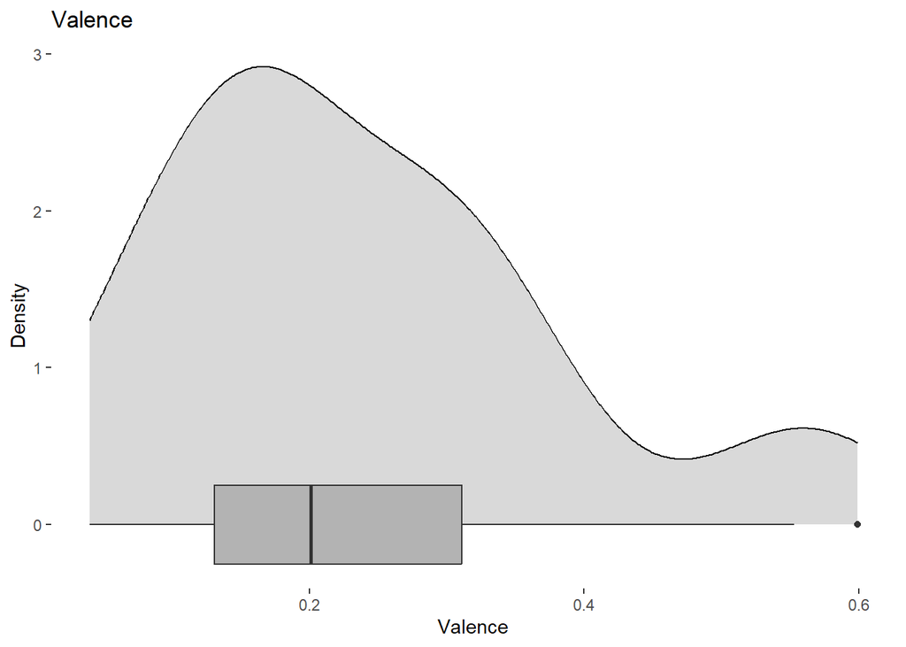

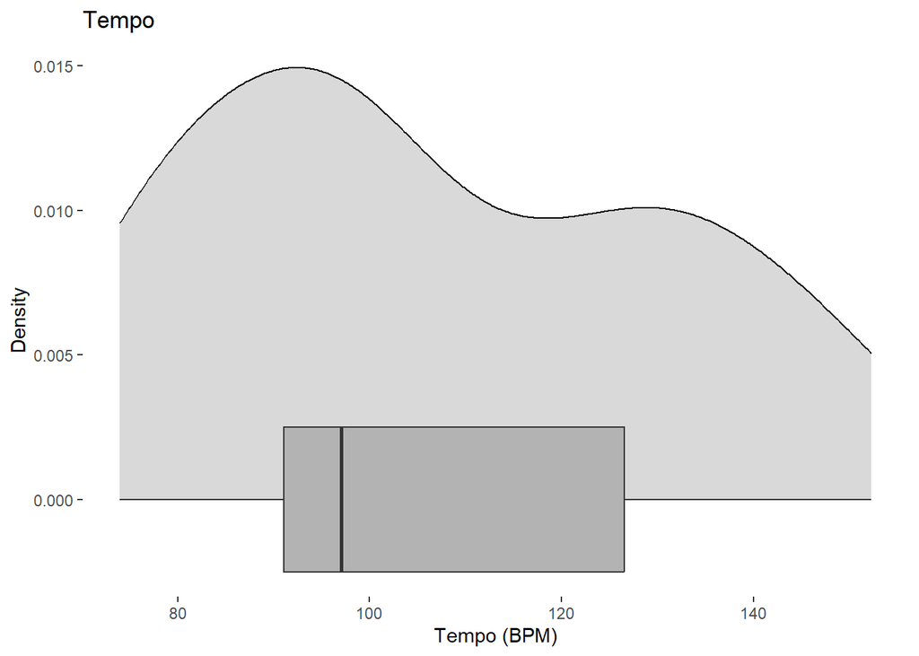

| Track Valence Scores Track Name | Track Valence Scores Album Name | Track Valence Scores Valence |
| --- | --- | --- |
| Holding you | X's | 0.599 |
| Silver Sable | X's | 0.553 |
| Baby Blue Movie | X's | 0.535 |

Note. Valence ranges from 0.0 (negative) to 1.0 (positive)

This then begs the question is that album just happier in general. A question which we will investigate with more boxplots because they are really usefull for questions like these.

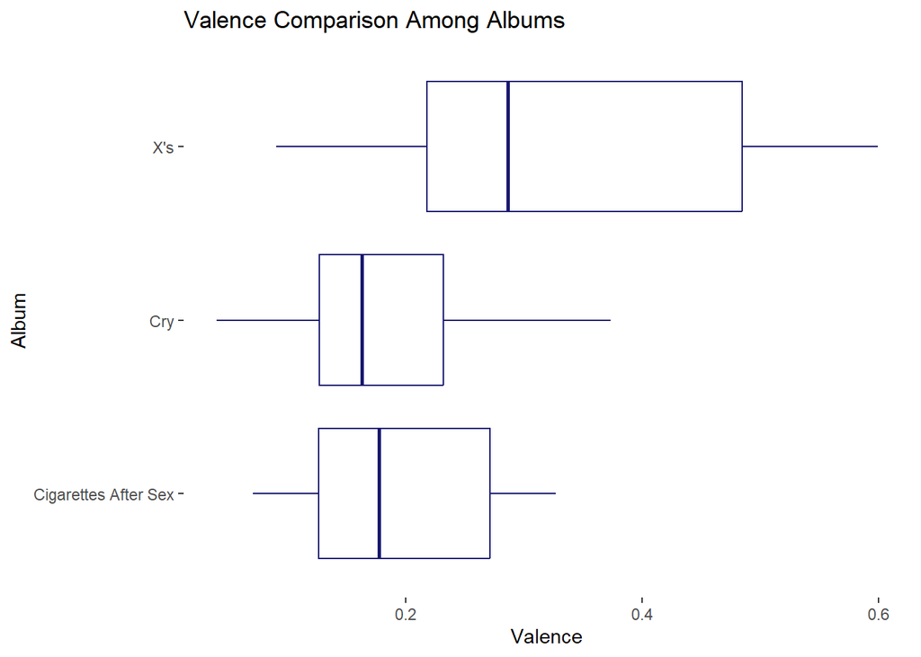

While we are doing this we might as well do the other two variables as well.

The answer seems to be yes X’s is visibly happier compared to their other albums. This has made me curious about the other variables so lets check.

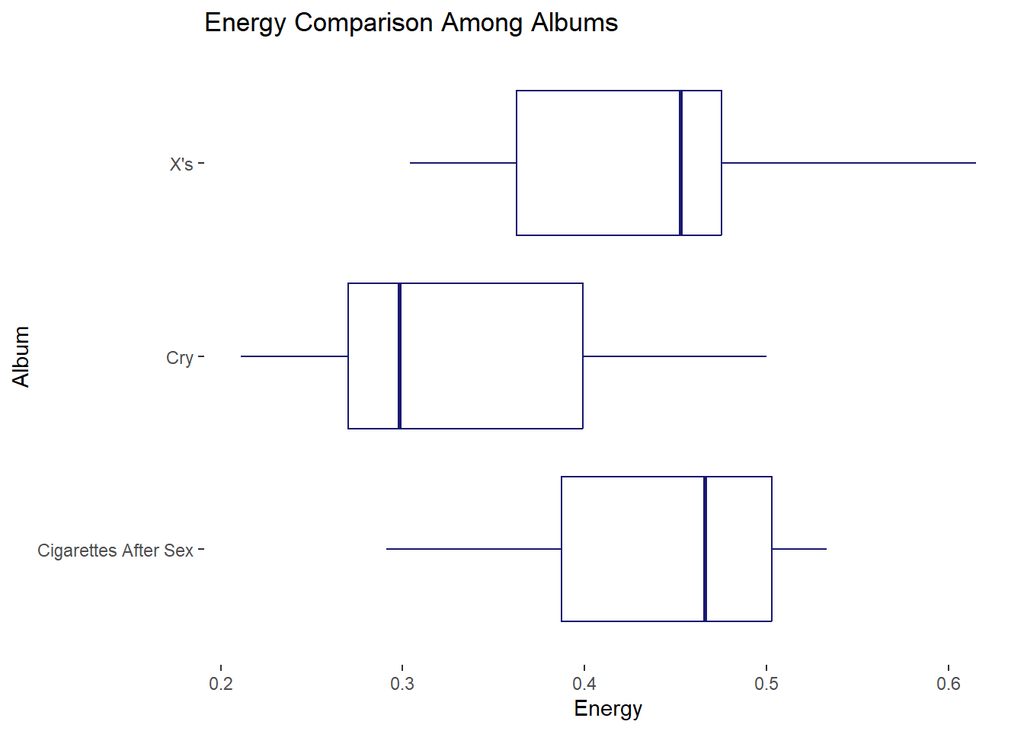

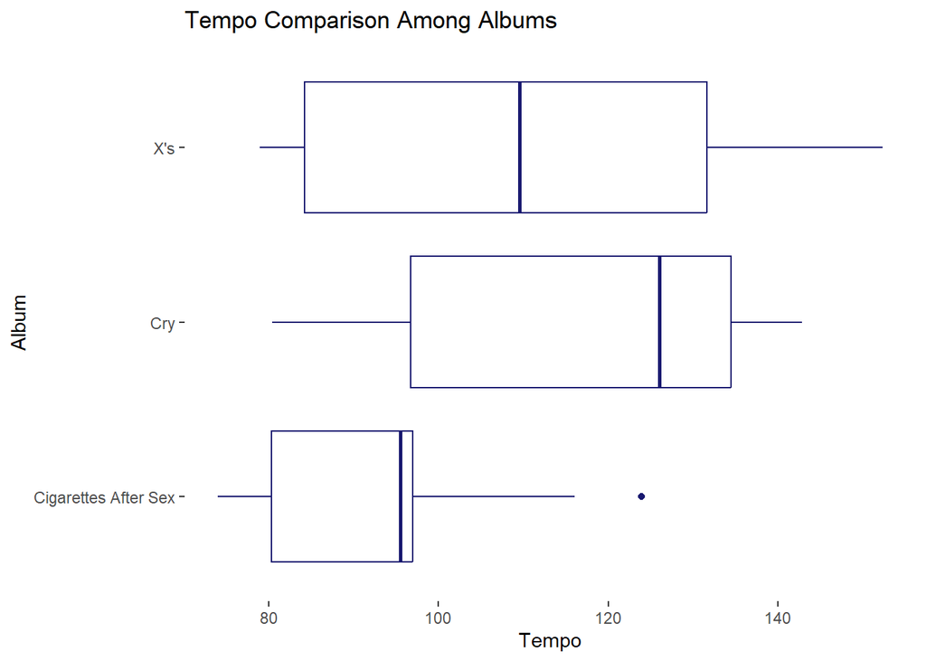

One thing I immediately notice is how different all three the albums are despite the claim’s made about them. But eye balling it is not very accurate nor scientific.

## 3D Analysis

If we assume that all three factors are equally important we can plot them in three 3D to see how similar they are. The closer they are together the more similar they are. In order to do this we do need to normalize tempo to a 0-1 scale as otherwise it would dis-proportionally impact the result. After we do this you get this cool 3D graphic

```r
# 1 Normalize tempo
df$tempo_n <- (df$tempo - min(df$tempo)) / (max(df$tempo) - min(df$tempo))

# 2. Create the 3D Plot
plot_ly(df,
        x = ~energy,
        y = ~valence,
        z = ~tempo_n,
        text = ~track_name,
        # Assign color to the album variable (replaces marker color = "black")
        color = ~album_name,
        type = "scatter3d",
        mode = "markers") %>%
  layout(
    scene = list(
      xaxis = list(title = "Energy"),
      yaxis = list(title = "Valence"),
      zaxis = list(title = "Normalized Tempo")
    ),
    title = "3D Song Analysis by Album"
  )
```

[interactive chart not shown]

The closer two songs are to each other the more similar they are, this allows us to find the most average CAS song. While visually it might not immediately become clear what song that is, we can calculate this rather easily by calculating the distance of every song to all the other song and then looking which has the lowest total distance. Similarly to how you do a sum of least squares test in statistics but now in 3D. And the result is:

```
[1] "Truly"
```

Here you can listen if and see for yourself if it *truly* is the most average song

[video not shown]

We can also infer from this how different CAS songs are from each other on average. for this we calculate the mean distance from each point to all the other ones.

```r
features <- df[, c("energy", "valence", "tempo_n")]
dist_matrix <- dist(features)
mean(dist_matrix)
```

```
[1] 0.4527191
```

This number does not tell us a lot on its own. That is why we should compare this to other artists. For this I have made a selection of different popular artists based on the amount of [streams they got in 2023 on spotify](https://newsroom.spotify.com/2023-11-29/top-songs-artists-podcasts-albums-trends-2023/). Sadly only: Taylor Swift, The Weekend, Travis Scott and Lana Del Rey had data available about them. We then do the exact same calculation as we did before and then put it in table to make it clear.

| Average Distance Comparison Among Artists Artist | Average Distance Comparison Among Artists Average_Distance |
| --- | --- |
| Cigarettes After Sex | 0.45 |
| Lana Del Rey | 0.46 |
| Taylor Swift | 0.46 |
| The Weeknd | 0.46 |
| Travis Scott | 0.42 |

Note. Lower values indicate greater similarity in audio features

## Conclusion

In summary Cigarettes After Sex has a very distinct and consistent style, that does however not mean that all of their songs/albums are the same. When compared to their other pop-artist peers the uniqueness of their songs is very similar. Therefor we can conclude after very serious scientific inquiry that the random fan on X was wrong. If we assume that all the variables hold equal weight which they don’t. As tempo is a part of the Valence measure. I could however not not find how much it contributed as I could not find a write up detailing how the Valence measurement is calculated. This invalidates the analysis, however this does not invalidate the method as if you would want to make a similar analysis you could use this as an example.

{% endraw %}